# The trip package

Michael Sumner

2019-04-15

# Introduction

Basic use of the trip package.

## Data input and validation

Tracking data is in essence a grouped series of one-dimensional data[^1] records.

It is *grouped* because we may track more than one object, each with its on independent time sequence.

It is *one-dimensional* because the topology of the data is a linear stream of values. It makes sense that time is constantly increasing, and it is the primary dimension of the process. (Location is often something that we must estimate, but time is usually directly measured and robust).

Commonly we have records in a data frame, and the primary workflow is to provide the `trip()` function with information about the spatial locations, the temporal data, and the grouping.

The data may contain any other columns, and in general they can be called anything and be in any order, but the simplest way to create a `trip` is to put the first four columns as X, Y, date-time, grouping.

```r
library(trip)
d <- data.frame(x=1:10,y=rnorm(10), tms=Sys.time() + 1:10, id=gl(2, 5))
tr <- trip(d)
summary(tr)
```

```
##
## Object of class trip
##   tripID ("id") No.Records   startTime ("tms")     endTime ("tms")
## 1             1          5 2019-04-15 13:04:34 2019-04-15 13:04:38
## 2             2          5 2019-04-15 13:04:39 2019-04-15 13:04:43
##   tripDuration tripDistance meanSpeed  maxSpeed
## 1       4 secs     756.9747  681277.3  916817.2
## 2       4 secs    1190.0092 1071008.2 1655201.1
##
## Total trip duration: 8 seconds (0 hours, 8 seconds)
##
## Derived from Spatial data:
##
## Object of class SpatialPointsDataFrame
## Coordinates:
##         min       max
## x  1.000000 10.000000
## y -2.520496  1.486936
## Is projected: FALSE
## proj4string :
## [+proj=longlat +ellps=WGS84 +datum=WGS84 +no_defs +towgs84=0,0,0]
## Number of points: 10
## Data attributes:
##       tms                      id
##  Min.   :2019-04-15 13:04:34   1:5
##  1st Qu.:2019-04-15 13:04:37   2:5
##  Median :2019-04-15 13:04:39
##  Mean   :2019-04-15 13:04:39
##  3rd Qu.:2019-04-15 13:04:41
##  Max.   :2019-04-15 13:04:43
```

(There may be only one group, but we have to be explicit, with a column that identifies at least one group).

When a print or summary is made the data are presented in terms of their grouping, with some handy summary values. When converting to `sf` or `sp` form as lines these summary values are recorded with each “multi”-line.

# Simple plotting

To plot a trip we use base graphics in the usual ways.

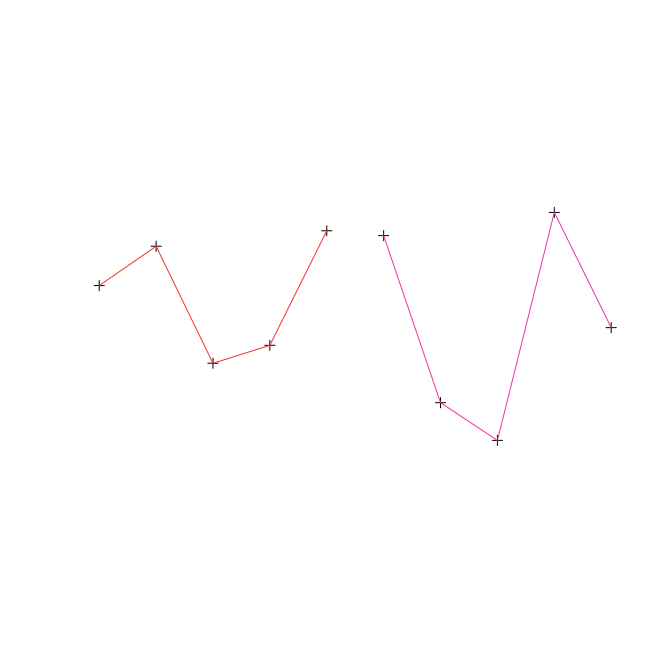

```r
plot(tr)
lines(tr)
```

The trip object acts as a `sp` data frame of points, but with the underlying grouping as lines when that is relevant.

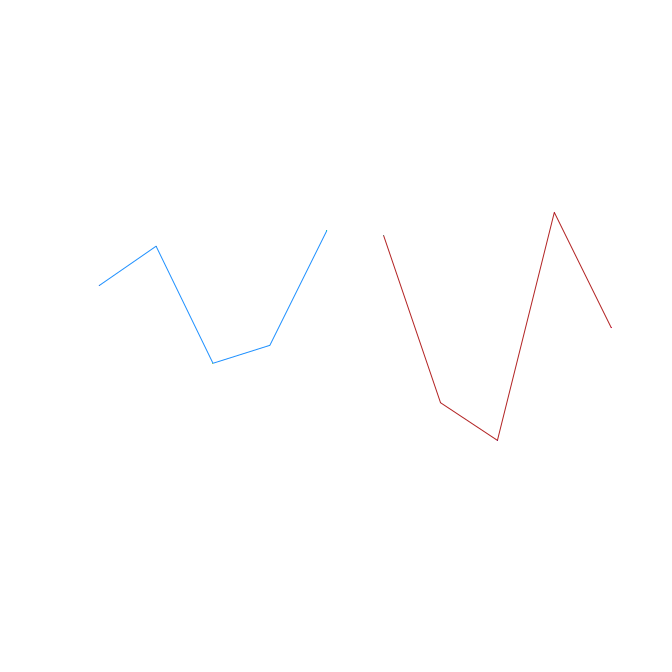

```r
plot(tr,pch = ".", col = rainbow(nrow(tr)))
lines(tr, col = c("dodgerblue", "firebrick"))
```

# Gridding for time spent

There is a key functionality to determine the *time spent in area* on a grid, by leveraging the `rasterize()` generic function in the raster package. Any raster object may be used, so the specification of pixel area, extent and map projection is up to the user. (The trip line segments must all fall within the raster).

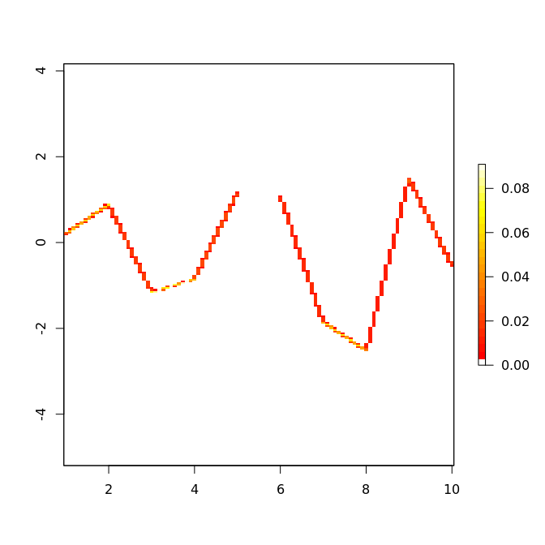

```r
tg <- rasterize(tr)
plot(tg, col = c("transparent", heat.colors(25)))
```

As with `raster::rasterize()` the `field` used may be chosen, by default the time difference between each point in a trip is used, and the final grid contains the sum of these durations.

There is an older version of this in the `tripGrid.interp` function that uses approximate methods by allowing interpolation to an ‘equal time’ step.

# Reading from Argos files

Service Argos has provide various message formats, and the `readArgos()` function understands some variants of the ‘PRV’ form. Multiple files can be provided, and all messages will be normalized and turned into a trip object with no need for the user to group or clean them in any way.

```r
argosfile <-
 system.file("extdata/argos/98feb.dat", package = "trip", mustWork = TRUE)
argos <- readArgos(argosfile)
```

```
##
## Longitudes contain values greater than 180, assuming proj.4 +over
##
##
##
##
##  Data fully validated: returning object of class  trip
```

```r
summary(argos)
```

```
##
## Object of class trip
##    tripID ("ptt") No.Records   startTime ("gmt")     endTime ("gmt")
## 1            2163        134 1998-02-01 03:32:32 1998-02-24 07:33:35
## 2            6072        150 1998-02-01 03:30:03 1998-02-28 23:16:54
## 3            6073        149 1998-02-03 20:47:38 1998-02-28 23:11:56
## 4            6074        194 1998-02-01 01:51:52 1998-02-28 09:27:23
## 5            6075        160 1998-02-01 17:25:23 1998-02-28 23:17:54
## 6            6076        157 1998-02-01 03:26:28 1998-02-24 07:34:53
## 7            9301        203 1998-02-01 03:33:42 1998-02-28 06:07:30
## 8            9302         87 1998-02-01 05:09:25 1998-02-26 16:10:40
## 9            9303         12 1998-02-01 01:07:29 1998-02-06 09:12:07
## 10           9373        207 1998-02-01 01:51:09 1998-02-24 07:36:01
## 11           9374        191 1998-02-02 15:34:44 1998-02-28 21:36:10
## 12           9375        109 1998-02-01 01:50:39 1998-02-27 03:48:20
## 13           9376        136 1998-02-01 17:26:47 1998-02-22 16:59:45
## 14           9377        115 1998-02-02 07:17:31 1998-02-22 23:48:03
##     tripDuration tripDistance  meanSpeed     maxSpeed
## 1   23.1674 days    1863.0570   6.432518    37.942286
## 2   27.8242 days    1892.3474   6.121462   145.272310
## 3  25.10021 days    1823.2853   5.996931   178.023461
## 4  27.31633 days    2238.5876  12.305419   577.145686
## 5   27.2448 days    1727.8244 114.413551 17359.733584
## 6  23.17251 days    2274.3382   8.749814   158.320598
## 7  27.10681 days    3103.7016  42.599268  6647.259782
## 8   25.4592 days    1033.1808   3.075486    24.619663
## 9  5.336551 days     159.9482   2.561213     7.672954
## 10 23.23949 days    2367.4532 165.291161 32266.087530
## 11   26.251 days    1861.8685  89.148217 15474.519777
## 12 26.08172 days    2528.5373  14.731275   502.195919
## 13 20.98123 days    1520.4642   5.334161    47.066037
## 14 20.68787 days    1163.4306   4.725903    49.112034
##
## Total trip duration: 28422949 seconds (7895 hours, 949 seconds)
##
## Derived from Spatial data:
##
## Object of class SpatialPointsDataFrame
## Coordinates:
##               min     max
```

[output cut: 17 more lines]

```
##  Z:  0   1998-02-04: 106   02:27:48:   3   Min.   :0   Min.   :401648599
##  B:403   1998-02-10: 106   15:36:45:   3   1st Qu.:0   1st Qu.:401649265
##  A:376   1998-02-09:  96   19:21:28:   3   Median :0   Median :401649474
##  0:704   1998-02-03:  95   03:34:41:   2   Mean   :0   Mean   :401649505
##  1:420   1998-02-20:  93   04:19:04:   2   3rd Qu.:0   3rd Qu.:401649747
##  2: 83   1998-02-18:  91   05:13:29:   2   Max.   :0   Max.   :401650517
##  3: 18   (Other)   :1417   (Other) :1989
##       gmt
##  Min.   :1998-02-01 01:07:29
##  1st Qu.:1998-02-07 16:19:52
##  Median :1998-02-13 04:40:36
##  Mean   :1998-02-13 20:18:48
##  3rd Qu.:1998-02-20 07:48:41
##  Max.   :1998-02-28 23:17:54
##
```

Note that the form of the coordinates is native to the PRV file, and in this case contains longitude values that are greater than 180. Some forms of these files provide wrapped forms, but in general the data are read as-is.

(We need “world2” because we are at 40W, but +360).

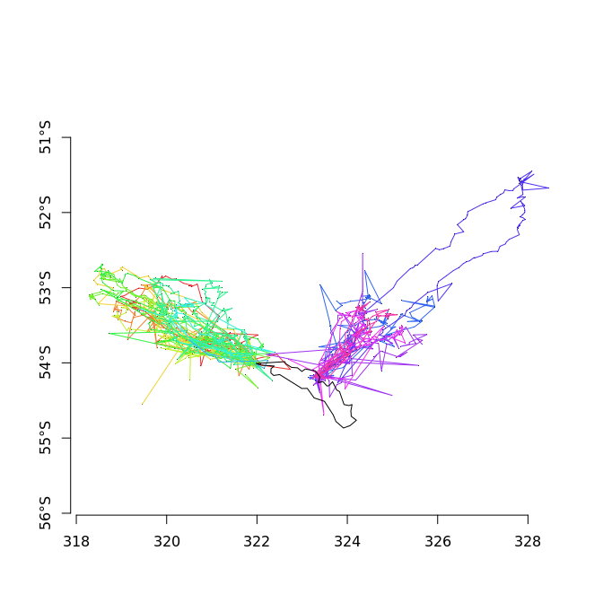

```r
plot(argos, pch = ".")
lines(argos)
maps::map("world2", add = TRUE)
axis(1)
sp::degAxis(2)
```

# Destructive filtering

There are some classic data filters based on speed and angle, and we may chain these together for some cheap improvements to track data, or use them separately.

```r
argos$spd <- speedfilter(argos, max.speed = 4)  ## km/h
mean(argos$spd)  ## more than 5% are too fast
```

```
## [1] 0.749002
```

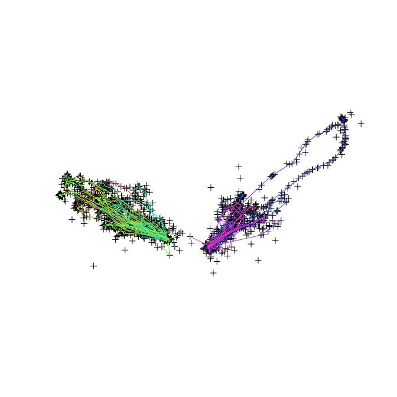

```r
plot(argos)
lines(argos[argos$spd & argos$class > "A", ])
```

```r
argos$sda <- sda(argos, smax = 12)  ## defaults based on argosfilter, Freitas et al. (2008)
mean(argos$sda)
```

```
## [1] 0.8687625
```

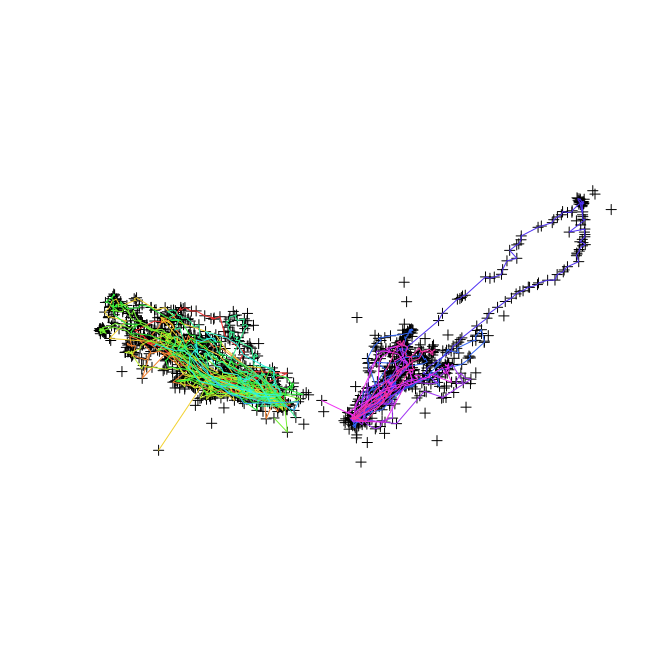

```r
plot(argos)
lines(argos[argos$sda, ])
```

# Map projections

Data may be stored in longitude latitude or using a map projection, an in-built data set uses the Azimuthal Equidistant family near the anti-meridian in the Bering Strait.

```r
raster::projection(walrus818)
```

```
## [1] "+proj=aeqd +ellps=WGS84 +lon_0=-170 +lat_0=70"
```

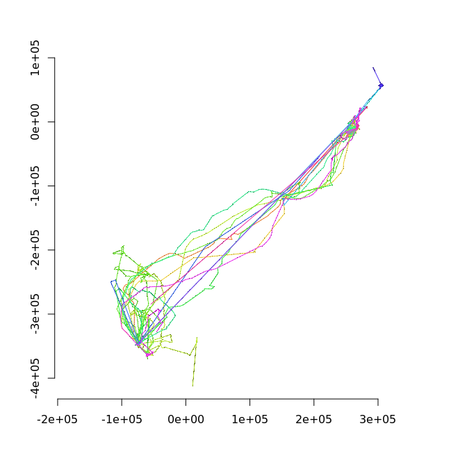

```r
data("walrus818")

plot(walrus818, pch = ".")
lines(walrus818)

axis(1)
axis(2)
```

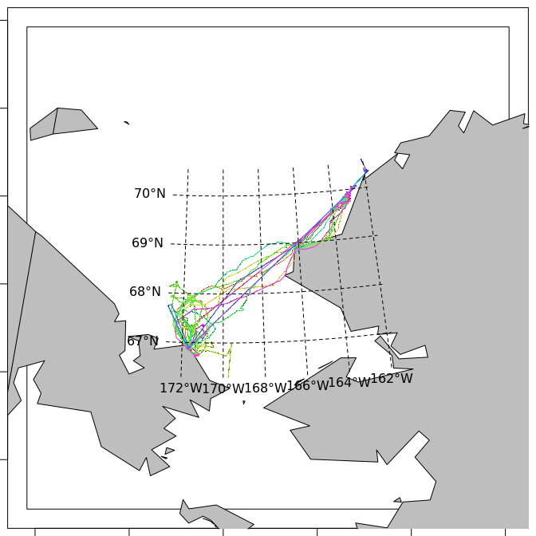

```r
library(maptools)
library(rgdal)
data(wrld_simpl)
world <- sp::spTransform(subset(wrld_simpl, coordinates(wrld_simpl)[,2] > 0), proj4string(walrus818))
p <- par(mar = rep(0.5, 4))
plot(raster::extent(walrus818) + 600000)
plot(walrus818, pch = ".", add = TRUE)
plot(world, add = TRUE, col = "grey")
lines(walrus818)
llgridlines(walrus818); par(p)
```

# Data conversions

There are various conversions from other tracking data types, the `trip()` function aims to be a helpful function like `raster::raster()`, simply understanding many formats.

It’s possible to export trips to Google Earth, for interacting with the time slider in continuous time. Use `write_track_kml()` to produce a ‘KML/KMZ’ file.

When converting to spatial forms we may choose multi-lines, points, or segments.

Conversion to points, in ‘sp’ or ‘spatstat’.

```r
## as points
as(walrus818, "SpatialPointsDataFrame")
```

```
## class       : SpatialPointsDataFrame
## features    : 10558
## extent      : -117277, 307789, -412557, 84896  (xmin, xmax, ymin, ymax)
## coord. ref. : +proj=aeqd +ellps=WGS84 +lon_0=-170 +lat_0=70
## variables   : 4
## names       : Deployment,              DataDT, Wet, Forage
## min values  :        353, 2009-09-15 04:00:00,   0,      0
## max values  :        444, 2010-10-20 19:00:00,   1,      1
```

```r
as(walrus818, "ppp")
```

```
## Marked planar point pattern: 10558 points
## Mark variables: Deployment, DataDT, Wet, Forage
## window: rectangle = [-117277, 307789] x [-412557, 84896] units
```

Conversion to lines, in ‘sp’, ‘sf’, or ‘adehabitatLT’.

```r
## as lines
as(walrus818, "SpatialLinesDataFrame")
```

```
## class       : SpatialLinesDataFrame
## features    : 14
## extent      : -117277, 307789, -412557, 84896  (xmin, xmax, ymin, ymax)
## coord. ref. : +proj=aeqd +ellps=WGS84 +lon_0=-170 +lat_0=70
## variables   : 4
## names       : tripID,           tripStart,             tripEnd, tripDur
## min values  :    353, 2009-09-15 04:00:00, 2009-09-30 19:00:00, 1195200
## max values  :    444, 2010-09-07 17:00:00, 2010-10-20 19:00:00, 5695200
```

```r
as(walrus818, "sf")
```

[output not shown]

```r
as(walrus818, "ltraj")
```

```
##
## *********** List of class ltraj ***********
##
## Type of the traject: Type II (time recorded)
## * Time zone: GMT *
## Irregular traject. Variable time lag between two locs
##
## Characteristics of the bursts:
##     id burst nb.reloc NAs          date.begin            date.end
## 1  353   353      160   0 2009-09-15 04:00:00 2009-09-30 19:00:00
## 2  354   354      813   0 2009-09-16 04:00:00 2009-10-20 00:00:00
## 3  355   355     1151   0 2009-09-16 04:00:00 2009-11-04 19:00:00
## 4  356   356     1534   0 2009-09-16 23:00:00 2009-11-21 21:00:00
## 5  357   357     1274   0 2009-09-16 23:00:00 2009-11-09 22:00:00
## 6  358   358      596   0 2009-09-16 23:00:00 2009-10-18 19:00:00
## 7  359   359     1053   0 2009-09-16 23:00:00 2009-10-30 19:00:00
## 8  361   361      556   0 2009-09-17 01:00:00 2009-11-06 04:00:00
## 9  362   362      301   0 2009-09-17 01:00:00 2009-10-03 17:00:00
## 10 366   366      405   0 2009-09-19 15:00:00 2009-10-12 20:00:00
## 11 367   367     1172   0 2009-09-17 01:00:00 2009-11-10 16:00:00
## 12 368   368      151   0 2009-09-19 02:00:00 2009-10-02 22:00:00
## 13 443   443     1035   0 2010-09-07 17:00:00 2010-10-20 19:00:00
## 14 444   444      357   0 2010-09-07 17:00:00 2010-09-28 05:00:00
##
##
##  infolocs provided. The following variables are available:
## [1] "pkey"
```

Conversions to segments, in ‘sp’, ‘spatstat’.

```r
## as segments
explode(walrus818)
```

```
## class       : SpatialLinesDataFrame
## features    : 10544
## extent      : -117277, 307789, -412557, 84896  (xmin, xmax, ymin, ymax)
## coord. ref. : +proj=aeqd +ellps=WGS84 +lon_0=-170 +lat_0=70
## variables   : 4
## names       :           starttime,             endtime, timedur,  id
## min values  : 2009-09-15 04:00:00, 2009-09-15 05:00:00,    3600, 353
## max values  : 2010-10-20 18:00:00, 2010-10-20 19:00:00, 2152800, 444
```

```r
as(walrus818, "psp")
```

```
## marked planar line segment pattern: 10544 line segments
## Mark variables:  origMarks, pattern
## window: rectangle = [-117277, 307789] x [-412557, 84896] units
```

[^1]: *One-dimensional, are you crazy?* Yes, the measurement process is one-dimensional and that is how we can arrange the primary data we collect. We collect location (x, y, z), time, and many other variables such as temperature, air pressure, happiness and colour, these are the geometry of our measurements, but the collection itself is very much a one-dimensional topology.